# Linear Regression - Predicting Individual Medical Costs Billed by Health Insurance

2024-04-29

MELCHIZEDEK ACKAH-BLAY

## Introduction

“The United States’ national health expenditure (NHE) grew 5.8% to $3.2 trillion in 2015 (i.e., $9,990 per person), which accounted for 17.8% of the nation’s gross domestic product (GDP). In seeking to control these unsustainable increases in healthcare costs, it is imperative that healthcare organizations can predict the likely future costs of individuals, so that care management resources can be efficiently targeted to those individuals at highest risk of incurring significant costs. Key stakeholders in these efforts to manage healthcare costs include health insurers, employers, society, and increasingly healthcare delivery organizations due to the transition from fee-for-service payment models to value-based payment models. For any given individual, insurers generally have the most comprehensive information on healthcare costs as they pay for care delivered across various healthcare delivery organizations.

Predicting healthcare costs for individuals using accurate prediction models is important for various stakeholders beyond health insurers, and for various purposes. For health insurers and increasingly healthcare delivery systems, accurate forecasts of likely costs can help with general business planning in addition to prioritizing the allocation of scarce care management resources. Moreover, for patients, knowing in advance their likely expenditures for the next year could potentially allow them to choose insurance plans with appropriate deductibles and premiums.”

Excerpt from https://www-ncbi-nlm-nih-gov.proxy-um.researchport.umd.edu/pmc/articles/PMC5977561/

## Exploratory Data Analysis

The dataset comprises a total of 1338 observations and 7 variables. Among these variables, categorical ones exhibit dominant trends. For instance, the most prevalent category within the variable representing the number of children covered by health insurance or dependents is 0. Similarly, regarding smoking habits, 79.5% of individuals are non-smokers. Additionally, the majority of individuals reside in the northwest and southwest regions at an equal rate of 24.3%.

In terms of continuous variables, key statistics offer insights into the dataset’s characteristics. The average age of individuals is 39.20703, with a variation from this mean indicated by a standard deviation of 14.04996. Likewise, the mean BMI (Body Mass Index) is 30.6634, with a standard deviation of 6.098187, reflecting the diversity in body weights relative to height. Furthermore, medical costs billed by health insurance exhibit a mean of 13270.42, with a standard deviation of 12110.01, showcasing the range of expenditures across individuals. It’s important to note that for this assignment, the variable representing the number of children is treated as categorical, providing a comprehensive understanding of the dataset’s composition

## Data Visualization

The boxplot for the smoker category shows that smokers have a much higher individual medical cost compared to non-smokers

The boxplot for the region category shows that people living in the northeast region have the highest median individual medical costs of all regions

There is a positive correlation between age and individual medical costs

Looking at the scatterplot for BMI vs individual medical costs, it appears to not show any correlation, however for individuals with a BMI of under 30, there is less variation in their individual medical cost. The range is 0 to 40,000 whereas for individuals with a 30+ BMI, the range is from 0 to over 60,000

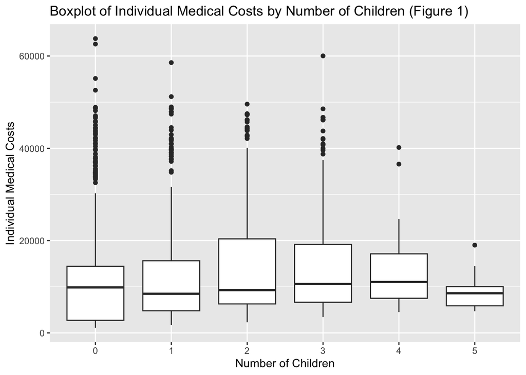

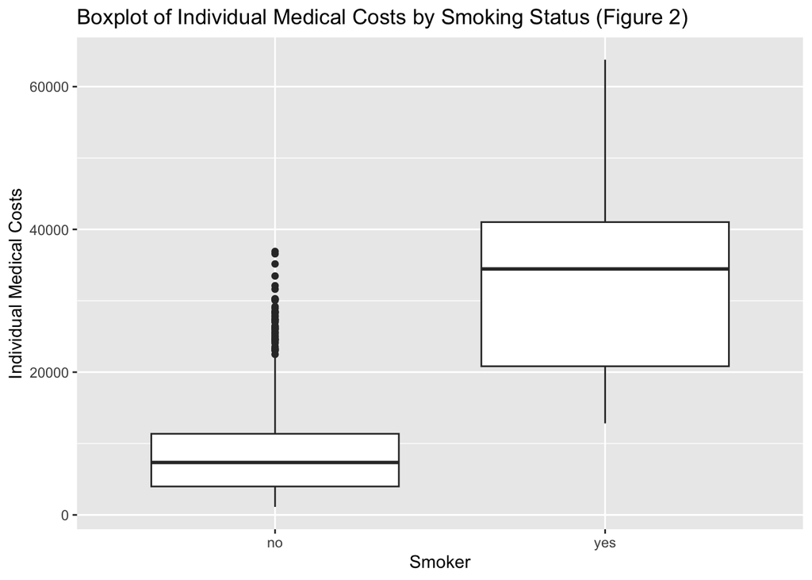

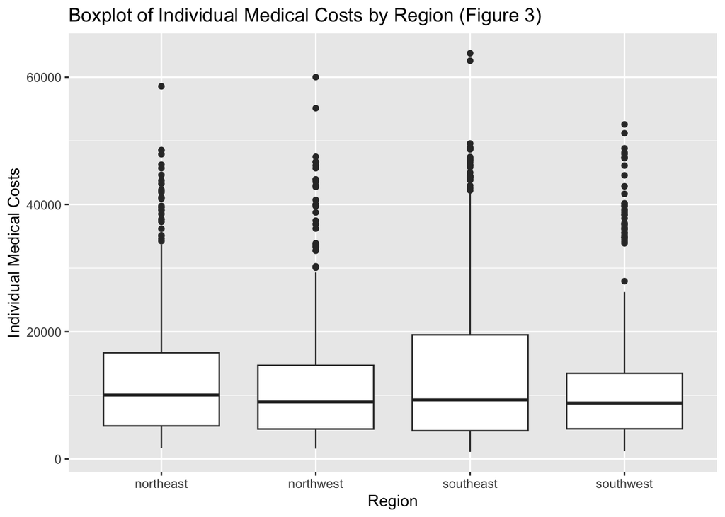

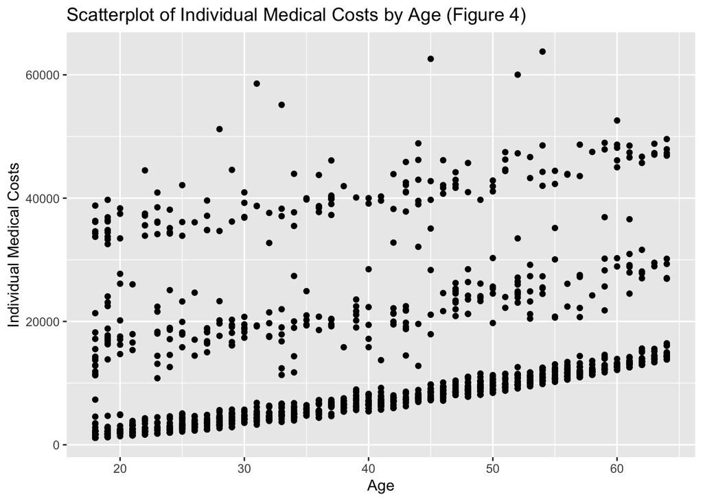

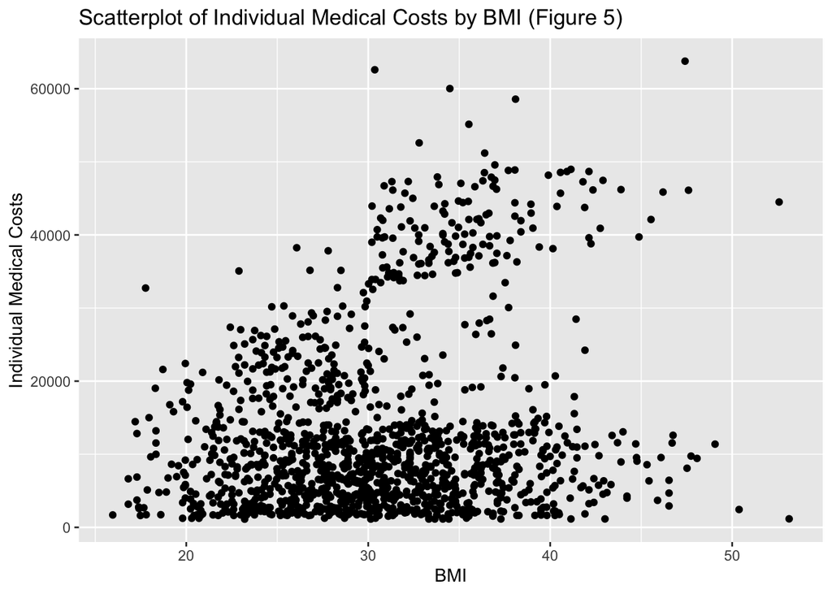

## Multiple Linear Regression Results

The slope coefficient for age is 256.9.This means that for every one-unit increase in age, there is an expected increase of 256.9 dollars in medical costs, holding all other variables constant. The slope coefficient for BMI is 339.2. This means that for every one-unit increase in BMI, there is an expected increase of 339.2 dollars in medical costs, holding all other variables constant. The slope coefficient for sex (Male) is -131.3. This means that being male is associated with a decrease of 131.3 dollars in medical costs compared to being female, holding all other variables constant. The slope coefficient for smoker (Yes) is 23848.5. This means that being a smoker is associated with a substantial increase of 23848.5 dollars in medical costs compared to non-smokers, holding all other variables constant. The slope coefficient for the number of children is 475.5. This means that for each additional child covered by health insurance or dependent, there is an expected increase of 475.5 dollars in medical costs, holding all other variables constant.The slope coefficients for the regions are -353.0 for Northwest, -1035.0 for Southeast, and -960.0 for Southwest.These coefficients indicate the difference in medical costs compared to the baseline region (Northeast), holding all other variables constant.

## Linear Regression Assumptions

The graph used to assess the normality of residuals is the “Normal Q-Q” plot. This plot examines whether the residuals follow a normal distribution. Points close to the diagonal line indicate normality. Since the points deviate significantly from the diagonal line especially at the top right region of the graph, it suggests that the normality assumption may be violated.

The graph used to assess the homogeneity of residuals variance is the “Scale-Location” (or “Spread-Location”) plot. This plot checks whether the spread of residuals remains consistent across different levels of the predictor variables. In the plot, the points appear to not be randomly scattered around a horizontal line. There are two large groups of points and the rest are scattered; This sugest some sort of heteroscedasticity, violating the assumption of homogeneity of residuals variance. Heteroscedasticity can lead to biased estimates of regression coefficients and inaccurate standard errors.

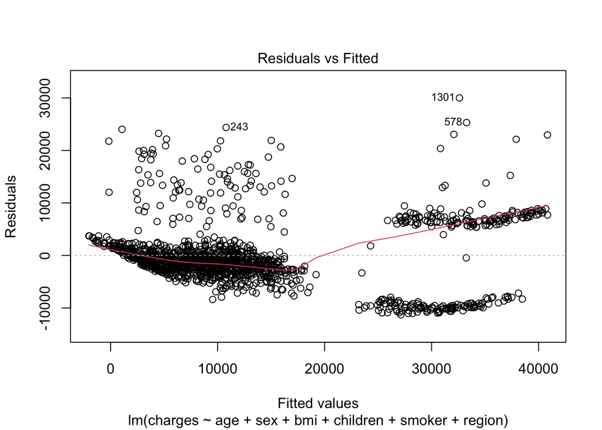

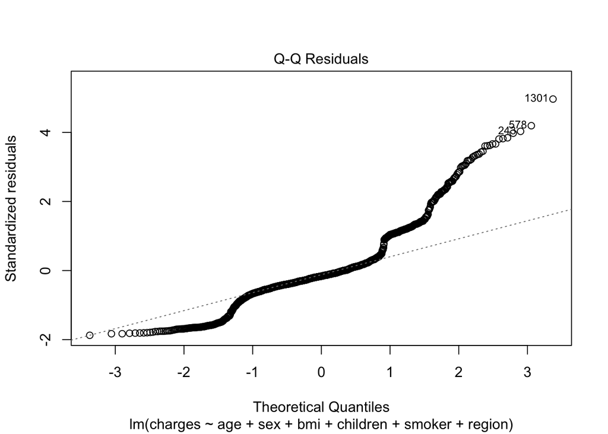

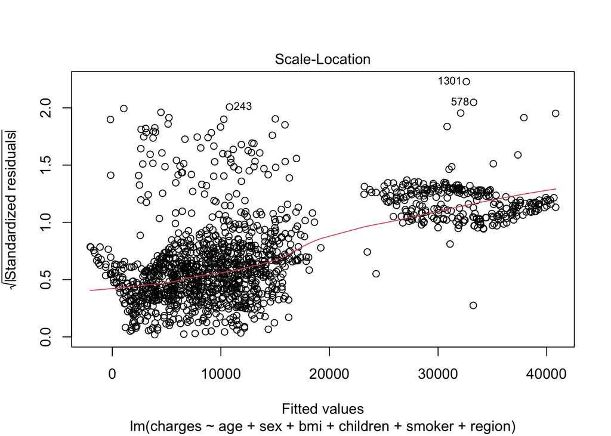

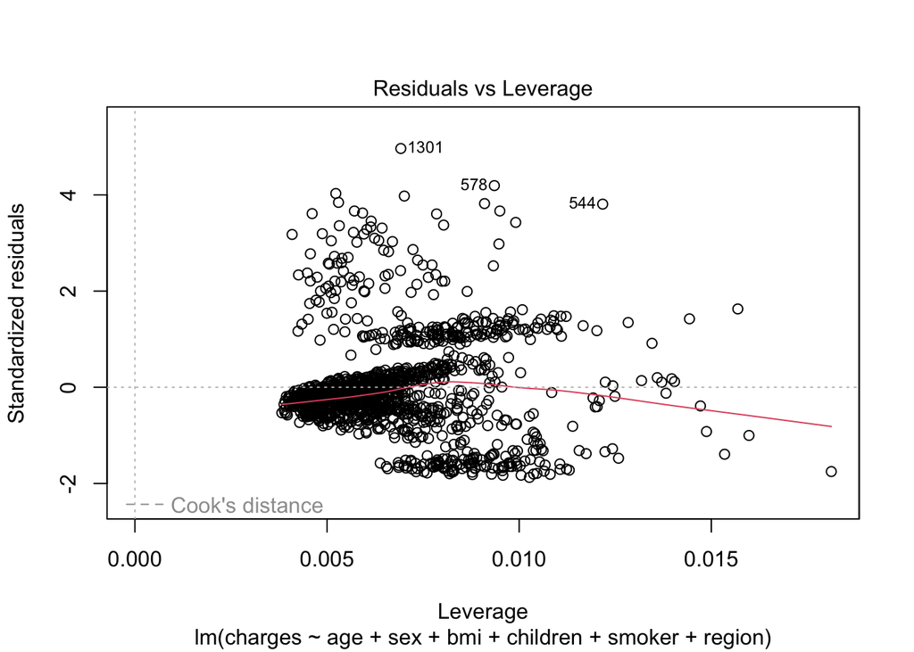